# Video Game Sales

### 18-10-2018

- 1. Introduction
- 2. Load Packages and Data
- 3. Exploring the data
- 4. Popularity Per Region

# **1. Introduction**

This is my first ever Python notebook. This will be a very simple exploratory data analysis of the data made avaiable by Kaggle at [https://www.kaggle.com/gregorut/videogamesales](http://www.kaggle.com/gregorut/videogamesales), where I will mostly use the *pandas* and *matplotlib* packages, as they are two of the most popular packages for data science.

# 2. Load Packages and Data

```python
import numpy as np
import pandas as pd
import matplotlib.pyplot as plt
#import seaborn as sns
```

```python
data = pd.read_csv('C:/Users/Joao/Documents/vgsales.csv')
```

# **3. Exploring the data**

The first thing to do is to get an idea of the shape of the data and the variables we have avaiable.

```python
data.head()
#data.tail()
#data.shape
#data.columns
```

|  | Rank | Name | Platform | Year | Genre | Publisher | NA_Sales | EU_Sales | JP_Sales | Other_Sales | Global_Sales |
| --- | --- | --- | --- | --- | --- | --- | --- | --- | --- | --- | --- |
| 0 | 1 | Wii Sports | Wii | 2006.0 | Sports | Nintendo | 41.49 | 29.02 | 3.77 | 8.46 | 82.74 |
| 1 | 2 | Super Mario Bros. | NES | 1985.0 | Platform | Nintendo | 29.08 | 3.58 | 6.81 | 0.77 | 40.24 |
| 2 | 3 | Mario Kart Wii | Wii | 2008.0 | Racing | Nintendo | 15.85 | 12.88 | 3.79 | 3.31 | 35.82 |
| 3 | 4 | Wii Sports Resort | Wii | 2009.0 | Sports | Nintendo | 15.75 | 11.01 | 3.28 | 2.96 | 33.00 |
| 4 | 5 | Pokemon Red/Pokemon Blue | GB | 1996.0 | Role-Playing | Nintendo | 11.27 | 8.89 | 10.22 | 1.00 | 31.37 |

```python
data.describe()
```

|  | Rank | Year | NA_Sales | EU_Sales | JP_Sales | Other_Sales | Global_Sales |
| --- | --- | --- | --- | --- | --- | --- | --- |
| count | 16598.000000 | 16327.000000 | 16598.000000 | 16598.000000 | 16598.000000 | 16598.000000 | 16598.000000 |
| mean | 8300.605254 | 2006.406443 | 0.264667 | 0.146652 | 0.077782 | 0.048063 | 0.537441 |
| std | 4791.853933 | 5.828981 | 0.816683 | 0.505351 | 0.309291 | 0.188588 | 1.555028 |
| min | 1.000000 | 1980.000000 | 0.000000 | 0.000000 | 0.000000 | 0.000000 | 0.010000 |
| 25% | 4151.250000 | 2003.000000 | 0.000000 | 0.000000 | 0.000000 | 0.000000 | 0.060000 |
| 50% | 8300.500000 | 2007.000000 | 0.080000 | 0.020000 | 0.000000 | 0.010000 | 0.170000 |
| 75% | 12449.750000 | 2010.000000 | 0.240000 | 0.110000 | 0.040000 | 0.040000 | 0.470000 |
| max | 16600.000000 | 2020.000000 | 41.490000 | 29.020000 | 10.220000 | 10.570000 | 82.740000 |

From our data, we can see the Top10 best selling games ever! The list we get has some of the games of the list https://en.wikipedia.org/wiki/List_of_best-selling_video_games#List . A clear omission seems to be Minecraft, and tetris being so low on our list shows me that some platform might be missing. Nonetheless, there's an agreement in most games from both lists.

```python
data.groupby(['Name']).sum()[['Global_Sales']].sort_values('Global_Sales',ascending=False).head(10)
```

| Name | Global_Sales |
| --- | --- |
| Wii Sports | 82.74 |
| Grand Theft Auto V | 55.92 |
| Super Mario Bros. | 45.31 |
| Tetris | 35.84 |
| Mario Kart Wii | 35.82 |
| Wii Sports Resort | 33.00 |
| Pokemon Red/Pokemon Blue | 31.37 |
| Call of Duty: Black Ops | 31.03 |
| Call of Duty: Modern Warfare 3 | 30.83 |
| New Super Mario Bros. | 30.01 |

The variable Global_sales is the sum of NA_Sales, EU_Sales, JP_Sales and Other Sales, and we can use it to know what's the best selling game each year!

This turned out to be a more difficult manipulation than expected, but I'm definetly learning!

We can see that since 2000, only in two years we saw a Microsoft console have the best selling game of the year, which can start to show the dominance of Playstation and Nintendo's consoles over Xbox.

```python
#data.groupby(['Year']).agg('max').Global_Sales
data.loc[ data.groupby(['Year'])['Global_Sales'].idxmax(), ['Name','Platform','Year','Global_Sales']].tail(20)
```

|  | Name | Platform | Year | Global_Sales |
| --- | --- | --- | --- | --- |
| 12 | Pokemon Gold/Pokemon Silver | GB | 1999.0 | 23.10 |
| 132 | Pokémon Crystal Version | GB | 2000.0 | 6.39 |
| 28 | Gran Turismo 3: A-Spec | PS2 | 2001.0 | 14.98 |
| 24 | Grand Theft Auto: Vice City | PS2 | 2002.0 | 16.15 |
| 104 | Need for Speed Underground | PS2 | 2003.0 | 7.20 |
| 17 | Grand Theft Auto: San Andreas | PS2 | 2004.0 | 20.81 |
| 10 | Nintendogs | DS | 2005.0 | 24.76 |
| 0 | Wii Sports | Wii | 2006.0 | 82.74 |
| 13 | Wii Fit | Wii | 2007.0 | 22.72 |
| 2 | Mario Kart Wii | Wii | 2008.0 | 35.82 |
| 3 | Wii Sports Resort | Wii | 2009.0 | 33.00 |
| 15 | Kinect Adventures! | X360 | 2010.0 | 21.82 |
| 29 | Call of Duty: Modern Warfare 3 | X360 | 2011.0 | 14.76 |
| 34 | Call of Duty: Black Ops II | PS3 | 2012.0 | 14.03 |
| 16 | Grand Theft Auto V | PS3 | 2013.0 | 21.40 |
| 44 | Grand Theft Auto V | PS4 | 2014.0 | 11.98 |
| 33 | Call of Duty: Black Ops 3 | PS4 | 2015.0 | 14.24 |
| 221 | FIFA 17 | PS4 | 2016.0 | 4.77 |
| 14390 | Phantasy Star Online 2 Episode 4: Deluxe Package | PS4 | 2017.0 | 0.03 |
| 5957 | Imagine: Makeup Artist | DS | 2020.0 | 0.29 |

Before analysing the data, I suspected that Playstation platforms tend to be more popular worldwide, although specifically in America Microsoft would be more popular, and the previous information supports my first assumption. To be sure, we should see the total sales by platform of all games, and we can see it in each of the areas avaiable (America, Europe, Japan, and Global).

```python
data.groupby(['Platform']).sum()[['NA_Sales','EU_Sales','JP_Sales','Global_Sales']].sort_values('Global_Sales',ascending=False).head(20)
```

| Platform | NA_Sales | EU_Sales | JP_Sales | Global_Sales |
| --- | --- | --- | --- | --- |
| PS2 | 583.84 | 339.29 | 139.20 | 1255.64 |
| X360 | 601.05 | 280.58 | 12.43 | 979.96 |
| PS3 | 392.26 | 343.71 | 79.99 | 957.84 |
| Wii | 507.71 | 268.38 | 69.35 | 926.71 |
| DS | 390.71 | 194.65 | 175.57 | 822.49 |
| PS | 336.51 | 213.60 | 139.82 | 730.66 |
| GBA | 187.54 | 75.25 | 47.33 | 318.50 |
| PSP | 108.99 | 68.25 | 76.79 | 296.28 |
| PS4 | 96.80 | 123.70 | 14.30 | 278.10 |
| PC | 93.28 | 139.68 | 0.17 | 258.82 |
| XB | 186.69 | 60.95 | 1.38 | 258.26 |
| GB | 114.32 | 47.82 | 85.12 | 255.45 |
| NES | 125.94 | 21.15 | 98.65 | 251.07 |
| 3DS | 78.87 | 58.52 | 97.35 | 247.46 |
| N64 | 139.02 | 41.06 | 34.22 | 218.88 |
| SNES | 61.23 | 19.04 | 116.55 | 200.05 |
| GC | 133.46 | 38.71 | 21.58 | 199.36 |
| XOne | 83.19 | 45.65 | 0.34 | 141.06 |
| 2600 | 90.60 | 5.47 | 0.00 | 97.08 |
| WiiU | 38.32 | 24.23 | 12.79 | 81.86 |

It's difficult to compare platforms from different years, specially since our Year ranges from 1980 to 2020, that's 40 years apart! How did the sales changed throughout the years? Naturally, we would expect that the global sales would increase accross the years, and we see that till we reach around 2010, where we see a huge drop. One explanation I can think of is that is coincidenes with the years of the 2009 financial crisis where a lot of people got affected by it.

The other explanation is if we don't have as many games recorded in those years. We can see by the second plot below that we have less unique games for those years after 2010, and that is probably the main reason for the decrese in global sales.

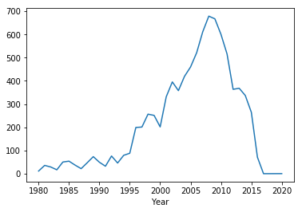

```python
data.groupby(['Year']).Global_Sales.sum().plot()
#data.groupby(['Year']).Global_Sales.sum().plot.bar()
plt.show()
```

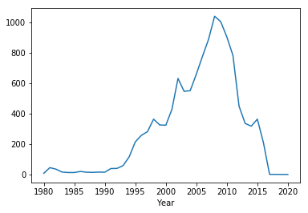

```python
#data.
data.groupby(['Year']).Name.nunique().plot()
plt.show()
```

```python
data.groupby(['Year']).Global_Sales.sum().idxmax()
#data.groupby(['Year']).Name.nunique().idxmax()
```

```
2008.0
```

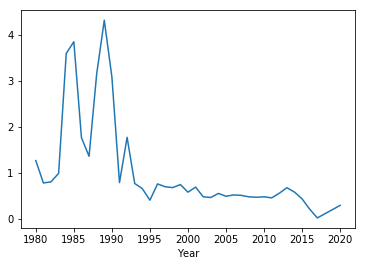

```python
data.groupby(['Year'])['Global_Sales'].mean().plot()
plt.show()
```

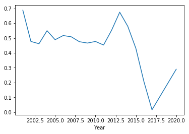

```python
data[data['Year']>2000].groupby(['Year'])['Global_Sales'].mean().plot()
plt.show()
```

Getting back to comparing the different platforms, something we can do is aggregate the platforms that belong to the same company. For example, Playstation, Playstation2, and Playstation, are all from Sony, and XBox and Xbox 360 are from Microsoft.

```python
data.Platform.nunique()
```

```
31
```

```python
data.Platform.unique()
```

```
array(['Wii', 'NES', 'GB', 'DS', 'X360', 'PS3', 'PS2', 'SNES', 'GBA',
       '3DS', 'PS4', 'N64', 'PS', 'XB', 'PC', '2600', 'PSP', 'XOne', 'GC',
       'WiiU', 'GEN', 'DC', 'PSV', 'SAT', 'SCD', 'WS', 'NG', 'TG16',
       '3DO', 'GG', 'PCFX'], dtype=object)
```

Based solely on my knowledege of the platforms, we create the variable *PlatformCompany* indicating to which company the platform belongs. I don't recognize some platforms so I'll fill it with "Other".

```python
def Platform_to_Owner (x):
    if x in ['PS','PS2','PS3','PS4','PSP','PSV']:
        return 'SONY'
    if x in ['Wii','NES','GB','DS','SNES','GBA','3DS','N64','GC','WiiU']:
        return 'NINTENDO'
    if x in ['X360','XB','XOne']:
        return 'MICROSOFT'
    return 'Other'
```

```python
data['PlatformCompany']=data.Platform.apply(lambda x: Platform_to_Owner (x))
#df.apply (lambda row: label_race (row),axis=1)
```

We see that Microsft has way less games in comparison with Sony and Nintendo, but this is explained by the fact that Sony and Nintendo not only have more consoles, but they have portable consoles which Microsoft doesn't make, so they have a bigger market.

```python
data.PlatformCompany.value_counts()
```

```
SONY         6648
NINTENDO     6272
MICROSOFT    2302
Other        1376
Name: PlatformCompany, dtype: int64
```

```python
data[(data['Year']>=2000) & (data['Year']<=2010) & (data['PlatformCompany'].isin(['SONY','NINTENDO']))] \
    .loc[:,['Year','PlatformCompany','Global_Sales']].groupby(['Year','PlatformCompany']).sum().reset_index()
```

|  | Year | PlatformCompany | Global_Sales |
| --- | --- | --- | --- |
| 0 | 2000.0 | NINTENDO | 53.83 |
| 1 | 2000.0 | SONY | 135.39 |
| 2 | 2001.0 | NINTENDO | 100.42 |
| 3 | 2001.0 | SONY | 201.95 |
| 4 | 2002.0 | NINTENDO | 126.39 |
| 5 | 2002.0 | SONY | 212.09 |
| 6 | 2003.0 | NINTENDO | 107.39 |
| 7 | 2003.0 | SONY | 186.34 |
| 8 | 2004.0 | NINTENDO | 124.44 |
| 9 | 2004.0 | SONY | 218.91 |
| 10 | 2005.0 | NINTENDO | 193.10 |
| 11 | 2005.0 | SONY | 204.88 |
| 12 | 2006.0 | NINTENDO | 275.70 |
| 13 | 2006.0 | SONY | 180.34 |
| 14 | 2007.0 | NINTENDO | 308.03 |
| 15 | 2007.0 | SONY | 197.29 |
| 16 | 2008.0 | NINTENDO | 322.05 |
| 17 | 2008.0 | SONY | 208.20 |
| 18 | 2009.0 | NINTENDO | 332.43 |
| 19 | 2009.0 | SONY | 196.86 |
| 20 | 2010.0 | NINTENDO | 219.78 |
| 21 | 2010.0 | SONY | 185.16 |

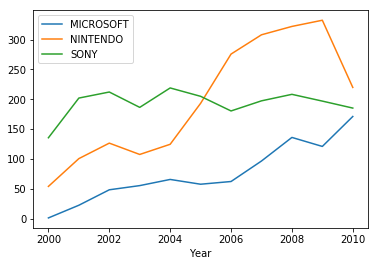

```python
temp=data[(data['Year']>=2000) & (data['Year']<=2010) & (data['PlatformCompany'].isin(['SONY','NINTENDO','MICROSOFT']))] \
    .loc[:,['Year','PlatformCompany','Global_Sales']].groupby(['Year','PlatformCompany']).sum().reset_index()

plot1 = plt.subplot(111)
temp.groupby(['PlatformCompany']).plot(y='Global_Sales', x='Year', kind='line',ax=plot1)
plot1.legend(['MICROSOFT','NINTENDO','SONY'])
plt.show()

#OR

#fig, ax = plt.subplots(figsize=(8,6))
#for label, df in temp.groupby('PlatformCompany'):
#    df.plot(x='Year',y='Global_Sales',kind="line", ax=ax, label=label)
# plt.legend()
```

# 4. Popularity Per Region

Lets see which genres are more popular in each region. I'll see for each region, how much of each genre it represents of the total sales in that region.

```python
data.drop(columns=['Rank', 'Name','Platform','Year','Publisher']).groupby(['Genre']).sum()
```

| Genre | NA_Sales | EU_Sales | JP_Sales | Other_Sales | Global_Sales |
| --- | --- | --- | --- | --- | --- |
| Action | 877.83 | 525.00 | 159.95 | 187.38 | 1751.18 |
| Adventure | 105.80 | 64.13 | 52.07 | 16.81 | 239.04 |
| Fighting | 223.59 | 101.32 | 87.35 | 36.68 | 448.91 |
| Misc | 410.24 | 215.98 | 107.76 | 75.32 | 809.96 |
| Platform | 447.05 | 201.63 | 130.77 | 51.59 | 831.37 |
| Puzzle | 123.78 | 50.78 | 57.31 | 12.55 | 244.95 |
| Racing | 359.42 | 238.39 | 56.69 | 77.27 | 732.04 |
| Role-Playing | 327.28 | 188.06 | 352.31 | 59.61 | 927.37 |
| Shooter | 582.60 | 313.27 | 38.28 | 102.69 | 1037.37 |
| Simulation | 183.31 | 113.38 | 63.70 | 31.52 | 392.20 |
| Sports | 683.35 | 376.85 | 135.37 | 134.97 | 1330.93 |
| Strategy | 68.70 | 45.34 | 49.46 | 11.36 | 175.12 |

```python
data.loc[:,['NA_Sales', 'EU_Sales','JP_Sales','Other_Sales','Global_Sales']].sum()
```

```
NA_Sales        4392.95
EU_Sales        2434.13
JP_Sales        1291.02
Other_Sales      797.75
Global_Sales    8920.44
dtype: float64
```

There's probably an easier way to do this, but I had to make two auxiliar objects to know the percentage of each genre in each region of the total sales.

Here we see something interesting. It seems that the Action genre is the most popular genre in every region except Japan. In Japan the most popular games seems to be RPGs (Interesting yes, but I already knew this! :p)

```python
Aux1=data.drop(columns=['Rank', 'Name','Platform','Year','Publisher']).groupby(['Genre']).sum()
Aux2=data.loc[:,['NA_Sales', 'EU_Sales','JP_Sales','Other_Sales','Global_Sales']].agg(['sum'])


100*Aux1.divide(Aux2.iloc[0],axis='columns').round(3)
```

| Genre | NA_Sales | EU_Sales | JP_Sales | Other_Sales | Global_Sales |
| --- | --- | --- | --- | --- | --- |
| Action | 20.0 | 21.6 | 12.4 | 23.5 | 19.6 |
| Adventure | 2.4 | 2.6 | 4.0 | 2.1 | 2.7 |
| Fighting | 5.1 | 4.2 | 6.8 | 4.6 | 5.0 |
| Misc | 9.3 | 8.9 | 8.3 | 9.4 | 9.1 |
| Platform | 10.2 | 8.3 | 10.1 | 6.5 | 9.3 |
| Puzzle | 2.8 | 2.1 | 4.4 | 1.6 | 2.7 |
| Racing | 8.2 | 9.8 | 4.4 | 9.7 | 8.2 |
| Role-Playing | 7.5 | 7.7 | 27.3 | 7.5 | 10.4 |
| Shooter | 13.3 | 12.9 | 3.0 | 12.9 | 11.6 |
| Simulation | 4.2 | 4.7 | 4.9 | 4.0 | 4.4 |
| Sports | 15.6 | 15.5 | 10.5 | 16.9 | 14.9 |
| Strategy | 1.6 | 1.9 | 3.8 | 1.4 | 2.0 |

# Auxiliar Functions:

```python
#data['Platform'].value_counts()
#data['Year'].value_counts()
#type(data['Year'].value_counts())
#data['Year'].value_counts()
#data[data['Platform']=='PS2'].sort_index().head()
#data.groupby(['Platform'])['Global_Sales'].agg('sum').sort_index()
#data.groupby(['Platform'])['Global_Sales'].sum().head()
#data.Platform.value_counts().head()
#data[['Year','Global_Sales']].plot()
#data.Year.value_counts().sort_index().tail()
#ype(data.groupby(['Year']).Global_Sales.sum())
#ype(data.groupby(['Year']).sum().Global_Sales.sum())
#data.groupby(['Year','Platform']).Global_Sales.sum() #grafico multiplas linhas
#data.groupby(['Year']).Global_Sales.sum().plot.bar()#data.groupby(['Year']).Global_Sales.sum().plot(kind='bar')
#data.plot(kind='scatter',x='Year',y='Global_Sales',color='red')
#plt.show()
```